# Lab2: Time series

Katarzyna Goch

21st Oct 2018

This is the report for the first assignment “Your own time series” from course “Analysis of Spatio-Temporal Data”, WS 2018/19.  
Supervisor: prof. Edzer Pebesma

# Time series description

## Time series 1: Air quality in Italy

### What is the time series about?

The dataset contains 9358 instances of hourly averaged responses from an array of 5 metal oxide chemical sensors embedded in an Air Quality Chemical Multisensor Device. The device was located on the field in a significantly polluted area, at road level,within an Italian city. Data were recorded from March 2004 to February 2005 (one year)representing the longest freely available recordings of on field deployed air quality chemical sensor devices responses. Ground Truth hourly averaged concentrations for CO, Non Metanic Hydrocarbons, Benzene, Total Nitrogen Oxides (NOx) and Nitrogen Dioxide (NO2) and were provided by a co-located reference certified analyzer. Evidences of cross-sensitivities as well as both concept and sensor drifts are present as described in De Vito et al., Sens. And Act. B, Vol. 129,2,2008, eventually affecting sensors concentration estimation capabilities. Missing values are tagged with -200 value. Data were obtained on 15th Oct 2018 from https://archive.ics.uci.edu/ml/datasets/Air+Quality#.

Names and description of the variables used in the database can be found below:

| Variable.name | Variable.definition |
| --- | --- |
| Date | Date (DD/MM/YYYY) |
| Time | Time (HH.MM.SS) |
| CO(GT) | True hourly averaged concentration CO in mg/m^3 (reference analyzer) |
| PT08S1(CO) | PT08.S1 (tin oxide) hourly averaged sensor response (nominally CO targeted) |
| NMHC(GT) | True hourly averaged overall Non Metanic HydroCarbons concentration in microg/m^3 (reference analyzer) |
| C6H6(GT) | True hourly averaged Benzene concentration in microg/m^3 (reference analyzer) |
| PT08S2(NMHC) | PT08.S2 (titania) hourly averaged sensor response (nominally NMHC targeted) |
| NOx(GT) | True hourly averaged NOx concentration in ppb (reference analyzer) |
| PT08S3(NOx) | PT08.S3 (tungsten oxide) hourly averaged sensor response (nominally NOx targeted) |
| NO2(GT) | True hourly averaged NO2 concentration in microg/m^3 (reference analyzer) |
| PT08S4(NO2) | PT08.S4 (tungsten oxide) hourly averaged sensor response (nominally NO2 targeted) |
| PT08S5(O3) | PT08.S5 (indium oxide) hourly averaged sensor response (nominally O3 targeted) |
| T | Temperature in °C |
| RH | Relative Humidity (%) |
| AH | AH Absolute Humidity |

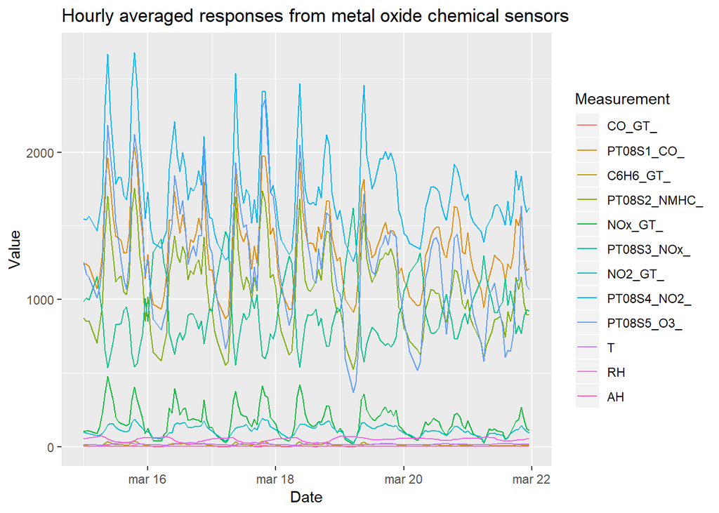

In the assignment the **true hourly averaged concentration CO** is analyzed.

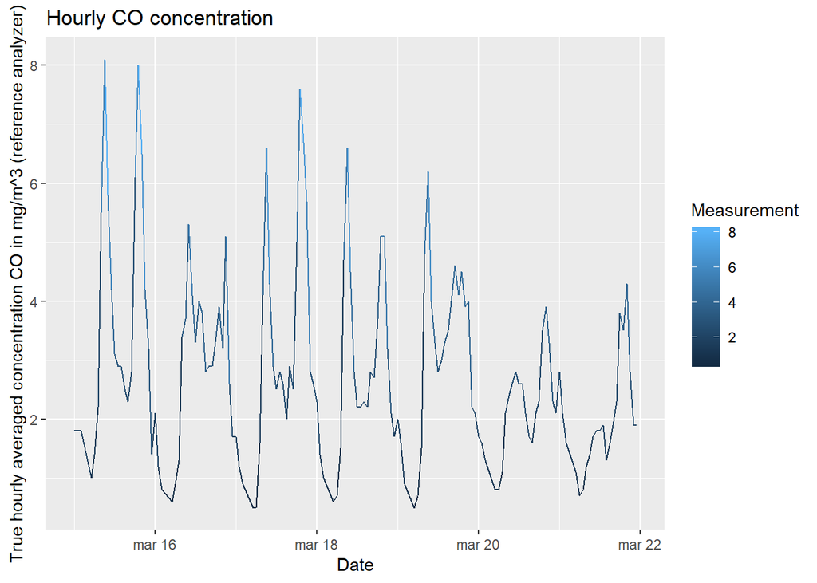

### What makes this data set a time series?

Data set covers hourly responses averages recorded by measuring equipment, listed in a time order. They create a sequence of temporally ordered observations. For each date and time there is easured an averaged concentration of CO.

### How long is the time series?

Time series data covers 7 days.

### What is the temporal extent of the time series (mention start and end time)

The time series were collected in the following period:  
Start date: 2004-03-15  
Stop date: 2004-03-21

### What is the temporal resolution, or frequency of the time series?

Time series were collected with an hourly frequency.

### Do the values in the time series refer to a time instance or a time interval?

Values in the time series refer to 1 hour time interval.

### Is the time series strictly regular, weakly regular, or irregular?

Time series is strictly regular.

## Time series 2: GDP for Poland

### What is the time series about?

Penn World Tables (PWT) version 9.0 is a database with information on relative levels of income, output, input and productivity, covering 182 countries.  
The PWT are described in Feenstra, Robert C., Robert Inklaar and Marcel P. Timmer (2015), “The Next Generation of the Penn World Table” American Economic Review, 105(10), 3150-3182, available for download at http://www.ggdc.net/pwt. Dataset was obtained on 21st Oct 2018.

Names and description of the variables used in the database can be found below:

| Variable.name | Variable.definition |
| --- | --- |
| countrycode | 3-letter ISO country code |
| country | Country name |
| currency_unit | Currency unit |
| year | Year |
| rgdpe | Expenditure-side real GDP at chained PPPs (in mil. 2011US$) |
| rgdpo | Output-side real GDP at chained PPPs (in mil. 2011US$) |
| pop | Population (in millions) |
| emp | Number of persons engaged (in millions) |
| avh | Average annual hours worked by persons engaged |
| hc | Human capital index, based on years of schooling and returns to education |
| ccon | Real consumption of households and government, at current PPPs (in mil. 2011US$) |
| cda | Real domestic absorption, (real consumption plus investment), at current PPPs (in mil. 2011US$) |
| cgdpe | Expenditure-side real GDP at current PPPs (in mil. 2011US$) |
| cgdpo | Output-side real GDP at current PPPs (in mil. 2011US$) |
| ck | Capital stock at current PPPs (in mil. 2011US$) |
| ctfp | TFP level at current PPPs (USA=1) |
| cwtfp | Welfare-relevant TFP levels at current PPPs (USA=1) |
| rgdpna | Real GDP at constant 2011 national prices (in mil. 2011US$) |
| rconna | Real consumption at constant 2011 national prices (in mil. 2011US$) |
| rdana | Real domestic absorption at constant 2011 national prices (in mil. 2011US$) |
| rkna | Capital stock at constant 2011 national prices (in mil. 2011US$) |
| rtfpna | TFP at constant national prices (2011=1) |
| rwtfpna | Welfare-relevant TFP at constant national prices (2011=1) |
| labsh | Share of labour compensation in GDP at current national prices |
| delta | Average depreciation rate of the capital stock |
| xr | Exchange rate, national currency/USD (market+estimated) |
| pl_con | Price level of CCON (PPP/XR), price level of USA GDPo in 2011=1 |
| pl_da | Price level of CDA (PPP/XR), price level of USA GDPo in 2011=1 |
| pl_gdpo | Price level of CGDPo (PPP/XR), price level of USA GDPo in 2011=1 |
| i_cig | 0/1/2: relative price data for consumption, investment and government is extrapolated (0), benchmark (1) or interpolated (2) |
| i_xm | 0/1/2: relative price data for exports and imports is extrapolated (0), benchmark (1) or interpolated (2) |
| i_xr | 0/1: the exchange rate is market-based (0) or estimated (1) |
| i_outlier | 0/1: the observation on pl_gdpe or pl_gdpo is not an outlier (0) or an outlier (1) |
| cor_exp | Correlation between expenditure shares of the country and the US (benchmark observations only) |
| statcap | Statistical capacity indicator (source: World Bank, developing countries only) |
| csh_c | Share of household consumption at current PPPs |
| csh_i | Share of gross capital formation at current PPPs |
| csh_g | Share of government consumption at current PPPs |
| csh_x | Share of merchandise exports at current PPPs |
| csh_m | Share of merchandise imports at current PPPs |
| csh_r | Share of residual trade and GDP statistical discrepancy at current PPPs |
| pl_c | Price level of household consumption, price level of USA GDPo in 2011=1 |
| pl_i | Price level of capital formation, price level of USA GDPo in 2011=1 |
| pl_g | Price level of government consumption, price level of USA GDPo in 2011=1 |
| pl_x | Price level of exports, price level of USA GDPo in 2011=1 |
| pl_m | Price level of imports, price level of USA GDPo in 2011=1 |
| pl_k | Price level of the capital stock, price level of USA in 2011=1 |

In the next assignment the **expenditure-side real GDP at chained purchasing power parity (PPPs) for Poland** is analyzed.

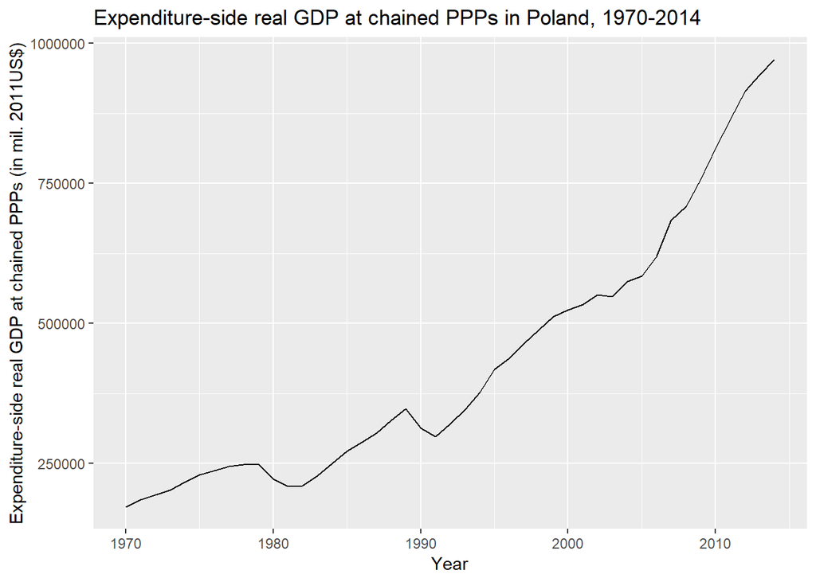

### What makes this data set a time series?

This data set provides series of annual indicators related to economy listed in a time order. Data set provide a sequence of temporally ordered observations. For each record there is a pair of time (given year) and observations (economical indicator).

### How long is the time series?

Time series data for Poland covers 45 years.

### What is the temporal extent of the time series (mention start and end time)

The time series for Poland cover period from 1970 to 2014. Ony year was provided in the dataset, therefore the last day of the year is assumed as a day and month value for the date:  
Start date: 1970-12-31  
Stop date: 2014-12-31

### What is the temporal resolution, or frequency of the time series?

Data were collected annually.

### Do the values in the time series refer to a time instance or a time interval?

Values in the time series refer to one year time interval.

### Is the time series strictly regular, weakly regular, or irregular?

Time series is strictly regular.